# Redundancy analysis

J. Ignacio Lucas Lledó

13/4/2020

```r
library(ggplot2)
library(gridExtra)
library(vegan)
library(Biostrings)
library(plyr)
library(e1071)
library(mice)
load('../2020-02-11/taxonomy.RData')
LH <- read.table('../../data/LifeHistoryVar.txt', header=TRUE, row.names=1)
ls()
```

```
## [1] "LH"           "SeqTabNoChim" "taxa"
```

# Underdetermination

**Redundancy analysis** was chosen because it does exactly what we need. It can tell what portion of variance in a set of response variables is explained by another set of variables. It is a combination of multivariate regression and principal component analysis. It is like a PCA of the objects described by the response variables, but *constrained* in such a way that the axis are chosen not to accumulate most of the variance, but most of the correlation with the set of explanatory variables. The resulting ordination maximizes the amount of variance in **Y** that is explained by **X**.

But it has a limitation. The matrix of explanatory variables **X** is supposed to have more cases or observations (in our case, **isolines**) than variables. That is of course not the case. Our explanatory variables are the several hundreds of amplicons identified in the gut microbiomes. This high-dimensionality problem is very common when using XX century statistics with XXI century data. Mathematically it is known as **underdetermination**. A linear system is considered underdetermined when it has more unknowns than equations.

In linear regression the equations are the different samples or observations and the *unknowns* are the regression coefficients corresponding to each independent variable and the intercept. Typically (last century) a linear regression was an *overdetermined* system: with more equations than unknowns. In that case, ordinary least squares can be used to find the approximate solution, or the exact one if it existed. Underdetermined systems seem harder to deal with. They have either no solution or infinitely many.

So, in the best case, when regressing life-history traits against the abundances of hundreds of amplicons, we would obtain an infinitude of possible combinations of coefficients. In general, it seems that spurious correlations would appear (Pezeshki et al. 2004). But in practice, the implementation may not even bother. That is the case with the `rda()` function in the `vegan` package: it does not use all the variables available, but just the few first ones.

# Canonical correlation analysis

An alternative to redundancy analysis is canonical correlation analysis (CCorA). The difference is analogous to that between regression and correlation. In CCorA the two matrices **X** and **Y** are considered in a symmetrical way, without the distinction between response and explanatory variables. CCorA finds *linear combinations* of **X** and **Y** that have maximum correlation with each other. It seems to me that CCorA avoids the underdetermination by reducing the dimensionality of both **X** and **Y**. The canonical correlations are correlations between pairs of linear combinations of variables in **X** and **Y**. There aren’t any multiple regressions involving the variables directly.

However, CCorA has a different problem. Because of the way canonical correlations are computed, the covariance matrices of **X** and **Y** must be invertible. When there are fewer observations than variables, the sample covariance matrix is not full rank (Legendre and Legendre 2012, 138), and therefore it is not invertible. I suspect there should be ways to run CCorA that do not depend on the inversion of sample covariance matrices. But I don’t know of any such implementation.

# The strategy

An alternative is to reduce the dimensionality of the amplicon abundance data before running the RDA. This is not ideal because the ordination of isolines based on amplicon abundances will not maximize correlation with the life-histroy traits, but just variance. Thus, if I run a PCA, the main axes will carry most of the variance but not necessarily most of the correlation. This approach will only be successful if the correlation signal is among the most variable amplicons, to be picked by the reduced number of dimensions. Even asuming that the existing correlations involve amplicons variable enough for that variation to be included in the first few axes of a PCA, an important question is how many principal components we should use in the RDA. It is tempting to use as many as possible to make sure that any correlation signal is still present. But, including too many components would very easily generate spurious, false positive correlations, as explained in Song et al. (2016). This is a model-selection problem, and it is related to the question of how many correlated signals there are (Song et al. 2016). It seems reasonable to assume that the number of correlated signals is small, even compared with the number of isolines.

A PCA would be adequate, in my view, despite of the warnings usually raised in ecological datasets. Legendre and Legendre (2012) discourages the use of PCA on species abundance data when there are many double zeros. The reason is that PCA preserves Euclidean distance between sites, which counts double absences as contributing to similarity. As discussed in `2020-03-25`, when using the abundance data as the independent variables, rather than the dependent, it is acceptable for double absences to contribute to similarity, because they are causaly equivalent.

About the high dimensionality problem, it does not seem to be fatal for PCA, as long as we are willing to use fewer than 24 components, which is the number of isolines.

# Abundance data

Instead of importing the prepared dataset from `2020-03-25`, I will prepare the matrices now again, to make this folder more self-contained. I start with the abundance data matrix. Recall I take the taxonomy information (`taxa`) and the abundance (`SeqTabNoChim`) from `2020-02-11`.

```r
# Renaming the amplicons
dna <- DNAStringSet(row.names(taxa))
names(dna) <- sprintf("A%04i", seq(dim(taxa)[1])) # Naming all available sequences, even filtered
row.names(taxa)        <- names(dna)[match(row.names(taxa), dna)]
colnames(SeqTabNoChim) <- names(dna)[match(colnames(SeqTabNoChim), dna)]
SampleData <- data.frame(
  age = factor(substr(row.names(SeqTabNoChim), 1, 1), levels=c('E','L'), labels=c('Early','Late')),
  isoline = factor(stringr::str_extract(rownames(SeqTabNoChim), "[[:digit:]]+"),
                   levels=as.character(c(6,10,11,12,14,15,17,19,20,22,23,24,25,26,27,28,29,30,31,33,35,36,38,39)),
                   ordered=FALSE),
  replicate = gsub("([EL][[:digit:]]+|.fastq.gz)", "", rownames(SeqTabNoChim)),
  seqrun = factor(1, levels=c(1,2))
)
run2 <- row.names(SeqTabNoChim) %in% c('E22C.fastq.gz', 'E23A.fastq.gz', 'E25A.fastq.gz',
                                       'E25B.fastq.gz', 'E25C.fastq.gz', 'E25D.fastq.gz',
                                       'E26A.fastq.gz', 'E26B.fastq.gz', 'E26C.fastq.gz',
                                       'E26D.fastq.gz', 'E27A.fastq.gz', 'E27B.fastq.gz',
                                       'E27C.fastq.gz', 'E28A.fastq.gz', 'E28B.fastq.gz',
                                       'E28C.fastq.gz', 'E28D.fastq.gz', 'E29A.fastq.gz',
                                       'E29B.fastq.gz', 'E29C.fastq.gz', 'E29D.fastq.gz',
                                       'E30A.fastq.gz', 'E30B.fastq.gz', 'E30C.fastq.gz',
                                       'E30D.fastq.gz', 'E31A.fastq.gz', 'E31B.fastq.gz',
                                       'E31C.fastq.gz', 'E31D.fastq.gz', 'E33A.fastq.gz',
                                       'E33B.fastq.gz', 'E33C.fastq.gz', 'E33D.fastq.gz',
                                       'E35A.fastq.gz', 'E35B.fastq.gz', 'E35C.fastq.gz',
                                       'E35D.fastq.gz', 'E36A.fastq.gz', 'E36B.fastq.gz',
                                       'E36C.fastq.gz', 'E36D.fastq.gz', 'E38A.fastq.gz',
                                       'E38B.fastq.gz', 'E38C.fastq.gz', 'E38D.fastq.gz',
                                       'E39A.fastq.gz', 'E39B.fastq.gz', 'E39C.fastq.gz',
                                       'E39D.fastq.gz', 'L23B.fastq.gz', 'L24C.fastq.gz',
                                       'L25A.fastq.gz', 'L25B.fastq.gz', 'L25C.fastq.gz',
                                       'L25D.fastq.gz', 'L26A.fastq.gz', 'L26B.fastq.gz',
                                       'L26C.fastq.gz', 'L26D.fastq.gz', 'L27A.fastq.gz',
                                       'L27B.fastq.gz', 'L27C.fastq.gz', 'L28A.fastq.gz',
                                       'L28B.fastq.gz', 'L28C.fastq.gz', 'L28D.fastq.gz',
                                       'L29A.fastq.gz', 'L29B.fastq.gz', 'L29C.fastq.gz',
                                       'L29D.fastq.gz', 'L30A.fastq.gz', 'L30B.fastq.gz',
                                       'L30C.fastq.gz', 'L30D.fastq.gz', 'L31A.fastq.gz',
                                       'L31B.fastq.gz', 'L31C.fastq.gz', 'L31D.fastq.gz',
                                       'L33A.fastq.gz', 'L33B.fastq.gz', 'L33C.fastq.gz',
                                       'L33D.fastq.gz', 'L35B.fastq.gz', 'L35C.fastq.gz',
                                       'L35D.fastq.gz', 'L36A.fastq.gz', 'L36B.fastq.gz',
                                       'L36C.fastq.gz', 'L36D.fastq.gz', 'L38A.fastq.gz',
                                       'L38B.fastq.gz', 'L38C.fastq.gz', 'L38D.fastq.gz',
                                       'L39A.fastq.gz', 'L39B.fastq.gz', 'L39C.fastq.gz',
                                       'L39D.fastq.gz')
SampleData$seqrun[run2] <- 2
row.names(SampleData) <- row.names(SeqTabNoChim)

isEarly <- SampleData$age == 'Early'
isLate  <- SampleData$age == 'Late'
EarlyAbundance <- SeqTabNoChim[isEarly,]
LateAbundance  <- SeqTabNoChim[isLate,]
EarlyIsoline <- SampleData[isEarly, 'isoline']
LateIsoline  <- SampleData[isLate,  'isoline']
# I found it impossible to do the following with plyr:
EA <- do.call(rbind, lapply(split(as.data.frame(EarlyAbundance), EarlyIsoline), colSums))
LA <- do.call(rbind, lapply(split(as.data.frame(LateAbundance),  LateIsoline),  colSums))
rm(EarlyAbundance, LateAbundance, EarlyIsoline, LateIsoline, isEarly, isLate, run2, SeqTabNoChim)
```

Now, `EA` and `LA` are matrices of *isoline* abundances early and late in life. That is, I added up abundances in replicates of the same isoline. I want to use all isolines, even though isolines 27 and 35 have very low counts among early samples. I will have to apply a strict filter on amplicons, to exclude those not abundant enough to get sampled in (early) isolines 27 and 35. In any case, removing low-frequency amplicons will help reduce the dimensionality of the data.

I prepare the filters before transforming the data.

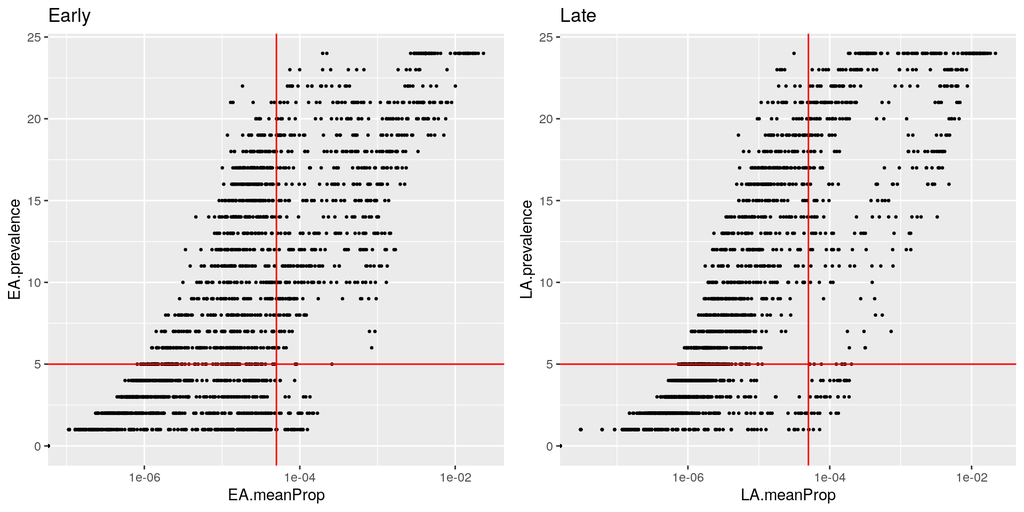

```r
# It would not make sense to estimate proportions after filtering.
# I transpose to keep amplicons in columns and isolines in rows
EA.prop <- t(apply(EA, 1, function(x) x / sum(x)))
LA.prop <- t(apply(LA, 1, function(x) x / sum(x)))

AbundanceSummary <- data.frame(
  EA.meanProp = apply(EA.prop, 2, mean),
  LA.meanProp = apply(LA.prop, 2, mean),
  EA.prevalence = colSums(EA > 0),
  LA.prevalence = colSums(LA > 0)
)
p1 <- ggplot(AbundanceSummary, aes(x=EA.meanProp, y=EA.prevalence)) +
  geom_point(size=0.5) + scale_x_log10() + ggtitle('Early') +
  geom_vline(xintercept=5.0e-5, color='red') + geom_hline(yintercept=5, color='red')
p2 <- ggplot(AbundanceSummary, aes(x=LA.meanProp, y=LA.prevalence)) +
  geom_point(size=0.5) + scale_x_log10() + ggtitle('Late') +
  geom_vline(xintercept=5.0e-5, color='red') + geom_hline(yintercept=5, color='red')
grid.arrange(p1, p2, nrow=1)
```

```r
EA.filter <- AbundanceSummary$EA.meanProp >= 5.0e-5 & AbundanceSummary$EA.prevalence >= 5
LA.filter <- AbundanceSummary$LA.meanProp >= 5.0e-5 & AbundanceSummary$LA.prevalence >= 5
```

Abundance data needs to be transformed because it is extremely skewed. In an accompanying report, `transformations.Rmd` I decide that the most adequate transformation is logarithmic, with an added constant equal to 1.0e-6. After transformation, the dataset will be further reduced by removing several amplicons the abundance distribution of which are too skewed after transformation.

```r
colnames(EA.prop) <- paste0('E', colnames(EA.prop))
colnames(LA.prop) <- paste0('L', colnames(LA.prop))
A <- cbind(EA.prop[,EA.filter], LA.prop[,LA.filter])
A.log <- log10(A + 1.0e-6)
A.log.skewness <- apply(A.log, 2, skewness)
A.filter <- abs(A.log.skewness) <= 1.0
A.log <- as.data.frame(A.log[, A.filter])
dim(A.log)
```

```
## [1]  24 752
```

# Principal Component Analysis

```r
# I pre-calculate the covariance matrix to prevent princomp() from complaining
# that there are not enough observations.
A.log.covariance <- cov.wt(A.log)
A.pca <- princomp(A.log, covmat = A.log.covariance, scores = TRUE)
```

Now, I can use the scores of the isolines on a subset of the principal components as the abundance data in an RDA. The question is how many components to use, always less than 24.

# Covariate: sequencing run

The sequencing run is a sample’s feature, not an isoline’s. However, it has a batch effect in microbiome composition. To remove such technical effect, I create below a vector with the proportion of samples from the second batch in each isoline. Most isolines belong entirely to one batch. Only three isolines differ in the proportion of batch 2 samples between early and late time points. To simplify, I will consider only the overall (not age-specific) proportion of second batch samples per isoline.

```r
batch <- sapply(split(SampleData, SampleData$isoline),
                function(x) sum(x$seqrun == 2) / length(x$seqrun))
# To make sure the order is the same as in abundance data:
batch <- batch[row.names(A)]
```

# Life history traits

First, I standardize the variables.

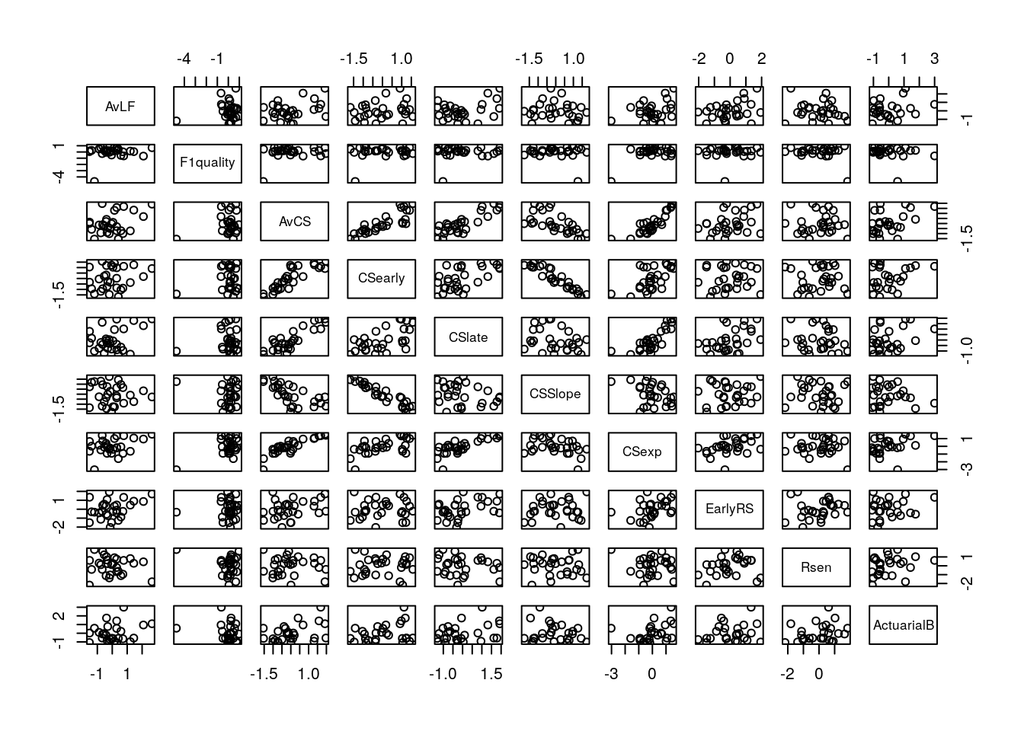

```r
LH <- apply(LH, 2, function(x) (x - mean(x, na.rm=TRUE)) / sd(x, na.rm=TRUE))
pairs(LH)
```

The isoline with a noticeable outlier in `F1quality` was not included in the gut microbiome study, and therefore will be dropped later. Then the distributions of the interesting variables will be much more acceptable.

Now, I need to impute the two missing values of `ActuarlialB`. A simple search online tells me that the preferred option is to use multiple imputed values, to get a sense of the uncertainty in the imputation. The function `mice` from the `MICE` package generates a set of imputations. Let’s run the RDA for the first of them, that I extract with the `complete` function.

I use the complete dataset of life-history traits to impute the two missing values, and then remove the isolines (rows) for which we don’t have microbiome data.

```r
LH.imp <- mice(LH, m=10)
LH.imp.1 <- complete(LH.imp, 1)
row.names(LH.imp.1) <- row.names(LH)
LH.imp.1 <- LH.imp.1[row.names(A), ]
```

# Redundancy analysis

I use first one imputation to run a complete analysis. Once I get a clear idea of what results we are most interested in, I can loop over the several imputations suggested by `mice` and summarize the alternative results.

Recall that the `rda()` function from the `vegan` package expects the left hand side of the input formula (or the `X` matrix) to be community composition data (species abundances), because most ecologists seem interested in explaining composition with environmental data, instead of using composition data to explain something else. That is why it will list the life-history traits under the *species* label.

Using the `batch` as a *condition*, I am effectively applying what they call **partial** redudancy analysis (pRDA). The problem with this approach is that the *R2 adjusted* cannot be computed.

At this point, I want to use the same life-history traits that Pau Carazo used to run a PCA previously, because they are very well selected and yielded reasonable results. The variables are six: early climbing speed (`CSearly`), climbing speed slope with age (`CSSlope`), early reproductive fitness (`EarlyRS`), reproductive senescence (`Rsen`), average life span (`AvLF`), and acceleration of mortality rate or $\beta$ component of a Gompertz fit on survival curve (`ActuarialB`).

```r
interesting <- c('CSearly', 'CSSlope', 'EarlyRS', 'Rsen', 'AvLF', 'ActuarialB')
RDA0 <- rda(LH.imp.1[, interesting] ~ Condition(batch),
            data = as.data.frame(A.pca$scores[,1:5]), scale=FALSE)
RDA5 <- rda(LH.imp.1[, interesting] ~ . + Condition(batch),
            data = as.data.frame(A.pca$scores[,1:5]), scale=FALSE)
```

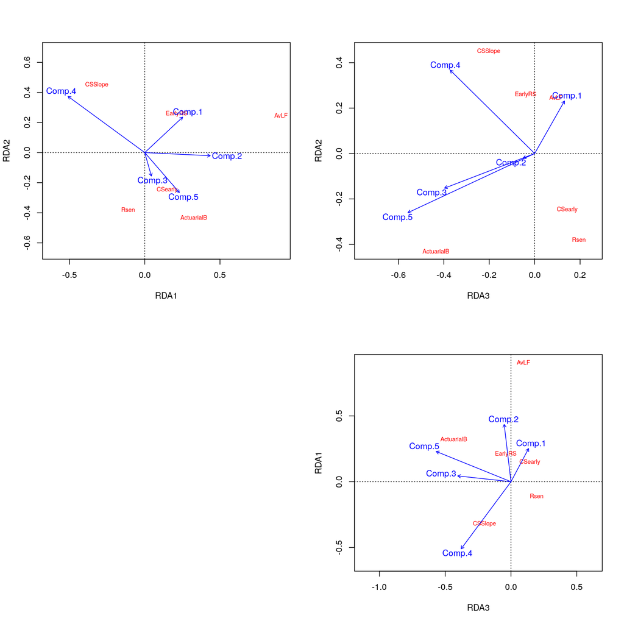

```r
par(mfrow=c(2,2))
  plot(RDA5, choices=c(1,2), display=c('sp','bp'), scaling=2)
  plot(RDA5, choices=c(3,2), display=c('sp','bp'), scaling=2)
  plot(0, type='n', axes=FALSE, ann=FALSE)
  plot(RDA5, choices=c(3,1), display=c('sp','bp'), scaling=2)
```

```r
par(mfrow=c(1,1))
```

This is just an example. I used one possible imputation, and I decided to include 5 components from the PCA on amplicon abundance data. Note that I fitted two models, one with 5 components and the other with none. I can compare them, to run a global test, as recommended by Blanchet, Legendre, and Borcard (2008):

```r
anova(RDA0, RDA5)
```

```
## Permutation tests for rda under reduced model
## Permutation: free
## Number of permutations: 999
##
## Model 1: LH.imp.1[, interesting] ~ Condition(batch)
## Model 2: LH.imp.1[, interesting] ~ Comp.1 + Comp.2 + Comp.3 + Comp.4 + Comp.5 + Condition(batch)
##   ResDf ResChiSquare Df ChiSquare      F Pr(>F)
## 1    22       5.4978
## 2    17       4.3589  5    1.1389 0.8884  0.581
```

According to this test, the variation along the 5 principal components in amplicon relative abundances among isolines does not really help explain the life-history traits’ variation. Before taking this result as definitive, I will save the data, close this document and move to a different folder.

```r
save(A, A.log, A.pca, batch, LH, LH.imp, taxa, file = 'RDA.RData')
```

Blanchet, F.G., P. Legendre, and D. Borcard. 2008. “Forward Selection of Explanatory Variables.” *Ecology* 89 (9): 2623–32. https://doi.org/10.1890/07-0986.1.

Legendre, Pierre, and Louis Legendre. 2012. *Numerical Ecology*. Amsterdam: Elsevier.

Pezeshki, A., L. L. Scharf, M. R. Azimi-Sadjadi, and M. Lundberg. 2004. “Empirical Canonical Correlation Analysis in Subspaces.” In *Conference Record of the Thirty-Eighth Asilomar Conference on Signals, Systems and Computers, 2004.*, 1:994–97 Vol.1. https://doi.org/10.1109/ACSSC.2004.1399288.

Song, Y., P.J. Schreier, D. Ramírez, and T. Hasija. 2016. “Canonical Correlation Analysis of High-Dimensional Data with Very Small Sample Support.” *Signal Processing* 128: 449–58. https://doi.org/10.1016/j.sigpro.2016.05.020.